# Simple logistic regression model

Tim D. Smith

July 11, 2015

# Exploring the Titanic data set

Start by loading some libraries and loading the training data:

```r
library(dplyr)
library(ggplot2)
library(GGally)
train = read.csv("train.csv")
```

Let’s plot the structured columns against each other and see what we learn:

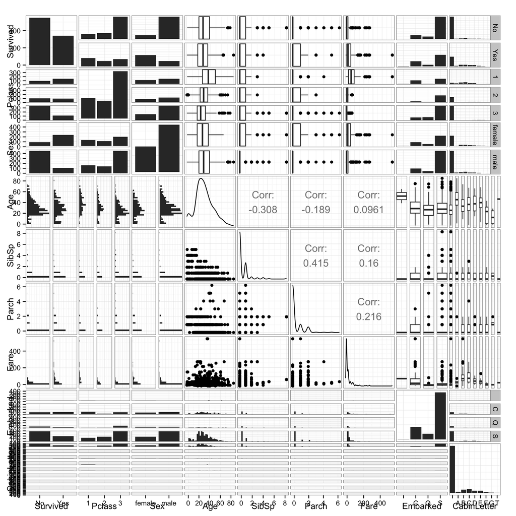

```r
skipcols = c("Cabin", "Ticket", "Name", "PassengerId")
train$CabinLetter = as.factor(gsub("^([A-Z]).*", "\\1", train$Cabin))
train$Survived = factor(train$Survived, levels=c(0,1), labels=c("No", "Yes"))
train$Pclass = as.factor(train$Pclass)
train_to_plot = train[,!names(train) %in% skipcols]
print(ggpairs(train_to_plot) + theme_bw())
```

There’s a lot going on here but we can extract some observations:

- Most passengers did not survive.
- The absolute number of survivors from each class is about the same, but there are many more nonsurvivors from passenger class 3.
- Women survived at a much higher rate.
- Age is not strongly linked to survival.
- Siblings & spouses are not linked to survival.
- More survivors had at least one parent or child than non-survivors, so there’s some protective effect.
- More survivors paid a higher fare than not.
- Passengers embarking at Southhampton were less likely to survive.

Let’s look at cabin letter more closely:

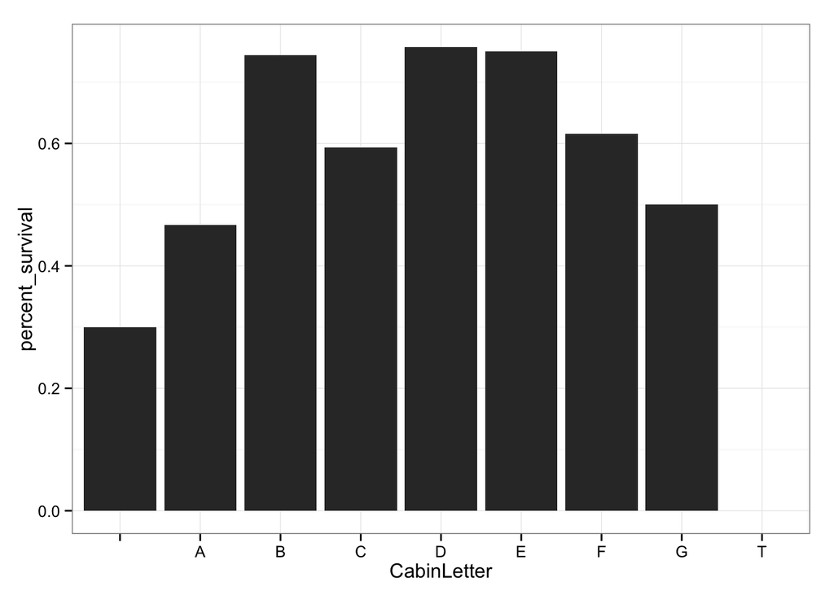

```r
fraction_yes = function(x) { sum(x == "Yes") / length(x) }
g = train %>%
  group_by(CabinLetter) %>%
  summarize(percent_survival=fraction_yes(Survived)) %>%
  ggplot(aes(CabinLetter, percent_survival)) +
    geom_bar(stat = "identity") +
    theme_bw()
print(g)
```

Survival was poor for poorly documented passengers and passengers in A and T cabins (though there was only one passenger in “T”, which is probably an error in my heuristic for extracting deck, so let’s not consider it).

# Logistic regression model

```r
prepare_for_fit = function(df) {
  train_logit = df
  train_logit$CabinLetter = as.factor(gsub("^([A-Z]).*", "\\1", train_logit$Cabin))
  train_logit$Pclass = as.factor(train_logit$Pclass)
  train_logit$BadCabin = train_logit$CabinLetter == "" | train_logit$CabinLetter == "A"
  train_logit$BadEmbarkation = train_logit$Embarked == "S"
  train_logit$ThirdClass = train_logit$Pclass == "3"
  train_logit
}

train_logit = prepare_for_fit(train)
train.model = glm(Survived ~ Sex + BadCabin + BadEmbarkation, data=train_logit, family="binomial")
print(summary(train.model))
```

```
##
## Call:
## glm(formula = Survived ~ Sex + BadCabin + BadEmbarkation, family = "binomial",
##     data = train_logit)
##
## Deviance Residuals:
##     Min       1Q   Median       3Q      Max
## -2.3212  -0.6468  -0.5168   0.7789   2.0394
##
## Coefficients:
##                    Estimate Std. Error z value Pr(>|z|)
## (Intercept)          2.6240     0.2586  10.147  < 2e-16 ***
## Sexmale             -2.4955     0.1769 -14.107  < 2e-16 ***
## BadCabinTRUE        -1.5866     0.2085  -7.609 2.77e-14 ***
## BadEmbarkationTRUE  -0.4879     0.1886  -2.587  0.00968 **
## ---
## Signif. codes:  0 '***' 0.001 '**' 0.01 '*' 0.05 '.' 0.1 ' ' 1
##
## (Dispersion parameter for binomial family taken to be 1)
##
##     Null deviance: 1186.66  on 890  degrees of freedom
## Residual deviance:  846.98  on 887  degrees of freedom
## AIC: 854.98
##
## Number of Fisher Scoring iterations: 4
```

We can ask naïvely how many of our passengers we classified correctly. (We need to partition our data-set into train and cross-validation segments to do this correctly…)

```r
sum((predict(train.model) > 0) == (train_logit$Survived == "Yes")) / length(train_logit$Survived)
```

```
## [1] 0.7845118
```

Not great, but not bad, either.

# Apply the logistic regression model to our test data set and save a CSV

```r
test = read.csv("test.csv")
test_logit = prepare_for_fit(test)
test$Survived = predict(train.model, test_logit) > 0
output = data.frame(PassengerId=test$PassengerId, Survived=as.numeric(test$Survived))
write.csv(output, "logistic_model.csv", row.names=FALSE)
```

# Result

This scores 0.76077 which, as we expect, is a little worse than it performs on the training set. This is a significant improvement over the trivial solution where we predict no survivors, which scores 0.62679.

# Adding fare data

We expect fare data to have a nonlinear relationship with survival probability, so let’s see if we can find a threshold score above which survival is most likely. We can do this using a ROC curve for fare vs. survival.

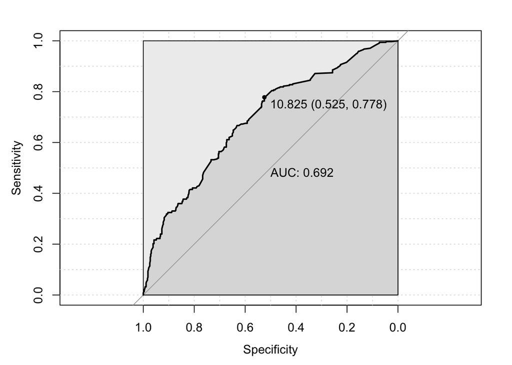

```r
library(pROC)
roc1 = roc(Survived ~ Fare, train,
           plot=TRUE, auc.polygon=TRUE, max.auc.polygon=TRUE, grid=TRUE,
           print.auc=TRUE, show.thres=TRUE, print.thres="best")
```

So let’s add that to our model and try again.

```r
train_logit$Expensive = train_logit$Fare > 10.825
train.model = glm(Survived ~ Sex + BadCabin + BadEmbarkation + Expensive, data=train_logit, family="binomial")
print(summary(train.model))
```

```
##
## Call:
## glm(formula = Survived ~ Sex + BadCabin + BadEmbarkation + Expensive,
##     family = "binomial", data = train_logit)
##
## Deviance Residuals:
##     Min       1Q   Median       3Q      Max
## -2.3205  -0.6037  -0.4385   0.6957   2.1860
##
## Coefficients:
##                    Estimate Std. Error z value Pr(>|z|)
## (Intercept)          1.9391     0.3150   6.156 7.47e-10 ***
## Sexmale             -2.3941     0.1785 -13.411  < 2e-16 ***
## BadCabinTRUE        -1.3268     0.2182  -6.082 1.19e-09 ***
## BadEmbarkationTRUE  -0.5114     0.1896  -2.697 0.006996 **
## ExpensiveTRUE        0.6832     0.1922   3.554 0.000379 ***
## ---
## Signif. codes:  0 '***' 0.001 '**' 0.01 '*' 0.05 '.' 0.1 ' ' 1
##
## (Dispersion parameter for binomial family taken to be 1)
##
##     Null deviance: 1186.66  on 890  degrees of freedom
## Residual deviance:  834.26  on 886  degrees of freedom
## AIC: 844.26
##
## Number of Fisher Scoring iterations: 4
```

```r
print(sum((predict(train.model) > 0) == (train_logit$Survived == "Yes")) / length(train_logit$Survived))
```

```
## [1] 0.7856341
```

It looks like this gives us only marginal improvement over our prior model, but let’s run it through the leaderboard anyway.

```r
test_logit$Fare[is.na(test_logit$Fare)] = median(test_logit$Fare, na.rm=TRUE)
test_logit$Expensive = test_logit$Fare > 10.825
test$Survived = predict(train.model, test_logit) > 0
output = data.frame(PassengerId=test$PassengerId, Survived=as.numeric(test$Survived))
write.csv(output, "logistic_model_fare.csv", row.names=FALSE)
```

This analysis makes us a little more pessimistic about the fate of two of our passengers:

```
tim@rocketman:titanic (master *)$ diff -U0 logistic_model.csv logistic_model_fare.csv
--- logistic_model.csv  2015-07-11 12:31:53.000000000 -0700
+++ logistic_model_fare.csv 2015-07-11 13:03:57.000000000 -0700
@@ -290 +290 @@
-1180,1
+1180,0
@@ -323 +323 @@
-1213,1
+1213,0
```

and actually scores worse than our simpler model, with a score of 0.75598. I think this is likely because the effect of fare was already encompassed by the effect of cabin and class.